# Prosper Loans - Interest Rate Predictors

## Dataset Overview

There are 113,937 loans in the dataset with 81 features. Variables consist of both numeric and categorical types. The attributes included variables that indicate both the borrowers' characteristics (such as whether or not they are homeowners), and the loans features (such as terms, status). 44384 data points were removed due to missing value and outliers before the investigation started.

## Investigation Overview

My main focus is on finding predictor variables for interest rates (`BorrowerRate`).

## Distribution of Borrower Rates

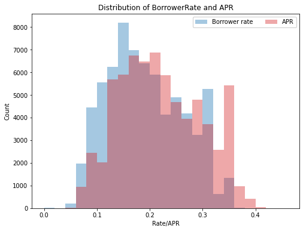

```python
# Borrower rate (and borrower APR) distribution
fig = plt.figure(figsize=(8, 6))
base_color_rate = sb.color_palette()[0]
base_color_apr = sb.color_palette()[3]
bins_rate = np.arange(0, loan.BorrowerRate.max()+0.05, 0.02)
bins_apr = np.arange(0, loan.BorrowerAPR.max()+0.05, 0.02)
plt.hist(data=loan, x='BorrowerRate', alpha=0.4, color=base_color_rate, bins=bins_rate);
plt.hist(data=loan, x='BorrowerAPR', alpha=0.4, color=base_color_apr, bins=bins_apr);
plt.legend(loc=1, ncol=2, framealpha=1, labels=['Borrower rate', 'APR']);
plt.xlabel('Rate/APR');
plt.ylabel('Count');
plt.title('Distribution of BorrowerRate and APR');
```

## Distribution of Employment Status

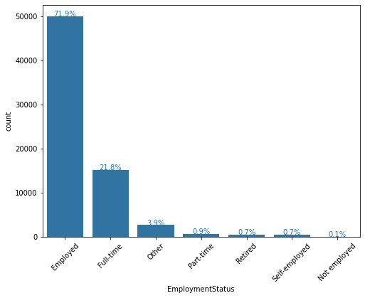

```python
# Employment status in relative frequencies
fig = plt.figure(figsize=(8, 6))
base_color = sb.color_palette()[0]
g_order = loan['EmploymentStatus'].value_counts().index
sb.countplot(data = loan, x = 'EmploymentStatus', color = base_color, order=g_order);

# Annotations
n_points = loan.shape[0]
status_counts = loan['EmploymentStatus'].value_counts()
locs, labels = plt.xticks() # get the current tick locations and labels

# Loop through each pair of locations and labels
for loc, label in zip(locs, labels):

    # get the text property for the label to get the correct count
    count = status_counts[label.get_text()]
    pct_string = '{:0.1f}%'.format(100*count/n_points)

    # print the annotation just below the top of the bar
    plt.text(loc, count-8, pct_string, ha = 'center', color = base_color)
    plt.xticks(rotation='45');
```

## Interest Rate vs. Prosper Scores/Terms/Loan Status

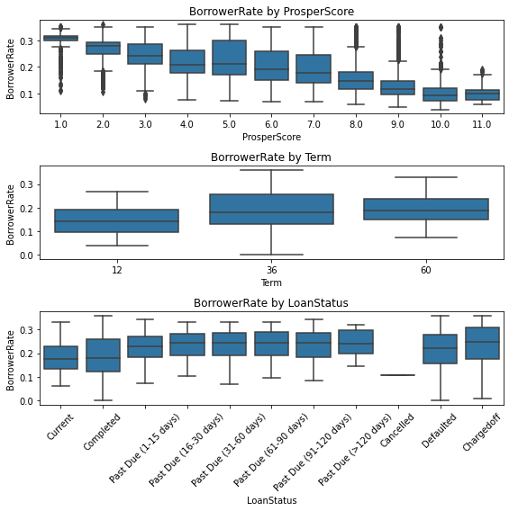

```python
fig, ax = plt.subplots(nrows=3, figsize = [8,8])
# Interest Rate vs. Prosper Scores
sb.boxplot(data=loan, x='ProsperScore', y='BorrowerRate', color=base_color, ax=ax[0]);
ax[0].set_title('BorrowerRate by ProsperScore');

# Interest Rate vs. Terms
sb.boxplot(data=loan, x='Term', y='BorrowerRate', color=base_color, ax=ax[1]);
ax[1].set_title('BorrowerRate by Term');

# Interest Rate vs. Loan Status
sb.boxplot(data=loan, x='LoanStatus', y='BorrowerRate', color=base_color, ax=ax[2]);
ax[2].set_title('BorrowerRate by LoanStatus');
plt.xticks(rotation='45');

plt.tight_layout()
```

## Prosper Scores Explained

- Stated monthly income
- Homeowner or not
- Income range  
  As `ProsperScore` increases, the percentage of borrowers in higher income range also increases. Same trend goes for `IsBorrowerHomeowner`, the higher the score, the more likely the borrower has a home.

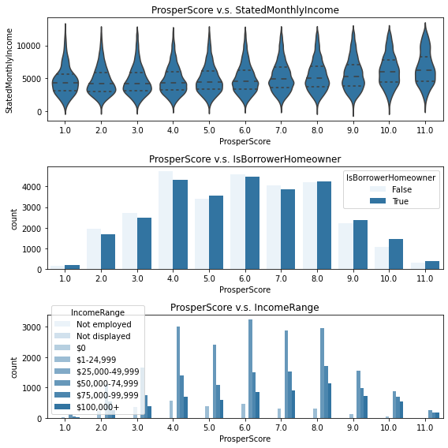

```python
fig, ax = plt.subplots(nrows=3, figsize = [8,8])
# ProsperScore v.s. StatedMonthlyIncome
sb.violinplot(data=loan, x='ProsperScore', y='StatedMonthlyIncome', color=base_color, inner='quartile', ax = ax[0]);
ax[0].set_title('ProsperScore v.s. StatedMonthlyIncome');
ax[0].set_yticklabels([],minor = True)

# ProsperScore v.s. IsBorrowerHomeowner
sb.countplot(data=loan, x='ProsperScore', hue='IsBorrowerHomeowner', color=base_color, ax=ax[1]);
ax[1].set_title('ProsperScore v.s. IsBorrowerHomeowner');

# ProsperScore v.s. IncomeRange
sb.countplot(data=loan, x='ProsperScore', hue='IncomeRange', color=base_color, ax=ax[2]);
ax[2].set_title('ProsperScore v.s. IncomeRange');

plt.tight_layout()
```

## Variables of Personal Financial Situation

- Home owner or not
- Available bank card credit
- Income range
- Monthly income

### Interest Rates across ProsperScore, by Homeowner or Not

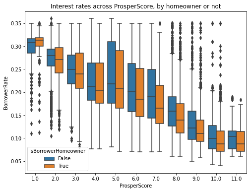

```python
# Interest rates across ProsperScore, by homeowner or not
fig = plt.figure(figsize=(8,6))
sb.boxplot(data=loan, x='ProsperScore', y='BorrowerRate', hue='IsBorrowerHomeowner');
plt.title('Interest rates across ProsperScore, by homeowner or not');
```

### Interest Rates across Terms, by Income Ranges

Within each income range group, the rate increases as amount of terms increases; overall, for the same amount of terms, people with higher income are able to be granted lower interest rate.

### Interest Rates across Different Loan Statuses, by Income Range

This graph indicates that for each loan status, it's clear that overall interest rates decrease as income ranges increase. But once a loan is defaulted or charged off, the interest rates can expect to maintain a same level as past due, instead of keeping growing.

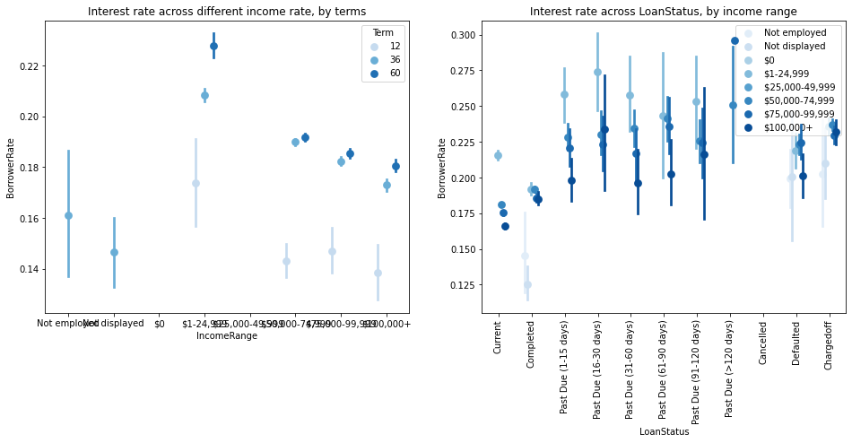

```python
#  Interest rates across terms, by income ranges
fig, ax = plt.subplots(ncols = 2, figsize = [16,6])
sb.pointplot(data = loan, x = 'IncomeRange', y = 'BorrowerRate', hue = 'Term',
           palette = 'Blues', linestyles = '', dodge = 0.4, ax = ax[0])
ax[0].set_title('Interest rate across different income rate, by terms')
ax[0].set_yticklabels([],minor = True)
plt.xticks(rotation='90')

#  Interest rates across different loan statuses, by income range
sb.pointplot(data = loan, x = 'LoanStatus', y = 'BorrowerRate', hue = 'IncomeRange',
             palette = 'Blues', linestyles = '', dodge = 0.4, ax = ax[1])
ax[1].set_title('Interest rate across LoanStatus, by income range')
ax[1].set_yticklabels([],minor = True)
plt.xticks(rotation='90')
plt.legend(loc='upper right')
plt.show();
```

### Available Bankcard Credits v.s. Interest Rates

Despite the amount of loans' terms, the amount of available bankcard credits show a negative correlation to interest rates.

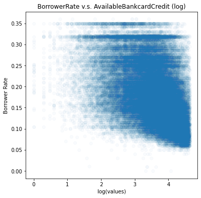

```python
# BorrowerRate v.s. AvailableBankcardCredit correlation on log scale
plt.figure(figsize = [6, 6])

# Log transformation
log_data = np.log10(loan.AvailableBankcardCredit)
bins_x = np.arange(0, log_data.max()+0.1, 0.1)
plt.scatter(data = loan, x = log_data, y = 'BorrowerRate', alpha = 1/40);

# Annotation
plt.ylabel('Borrower Rate');
plt.xlabel('log(values)');
plt.title('BorrowerRate v.s. AvailableBankcardCredit (log)');
```

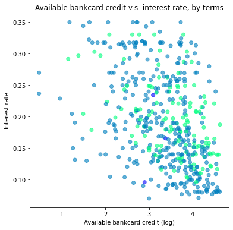

```python
# Available bankcard credit v.s. interest rate, by home owner or not
# Sampling data points from original DataFrame
samples = np.random.choice(loan.shape[0], 500, replace = False)
loan_samp = loan.iloc[samples,:]
# Log transformation
log_data = np.log10(loan_samp.AvailableBankcardCredit)
# Plotting
fig = plt.figure(figsize=(6, 6))
plt.scatter(data = loan_samp, x = log_data, y = 'BorrowerRate', c = 'Term', alpha=0.6, cmap = 'winter');
# Annotation and colors
plt.title('Available bankcard credit v.s. interest rate, by terms');
plt.xlabel('Available bankcard credit (log)');
plt.ylabel('Interest rate');

# Ticks

# Legend

plt.show()
```

### Available bankcard credit v.s. interest rate, by prosper score

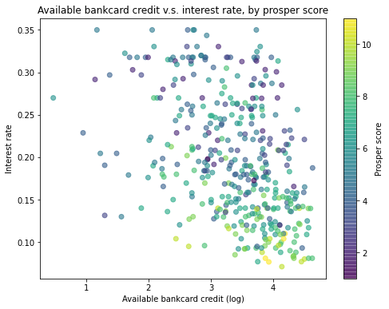

```python
# Available bankcard credit v.s. interest rate, by prosper score
# Log transformation
log_data = np.log10(loan_samp.AvailableBankcardCredit)
# Plotting 2
fig = plt.figure(figsize = [8,6]);
plt.scatter(data = loan_samp, x = log_data, y = 'BorrowerRate', c = 'ProsperScore', cmap = 'viridis', alpha=0.6);
# Annotation and colors
plt.title('Available bankcard credit v.s. interest rate, by prosper score');
plt.xlabel('Available bankcard credit (log)');
plt.ylabel('Interest rate');
# Legend
plt.colorbar(label='Prosper score')

plt.show()
```

### Lower bank Card Credits Can be a Barrier to Lowest Rates

For borrowers who have the lower interest rate, almost all of them have high bank card credits, whereas stated monthly income is not obviously correlated with the rates.

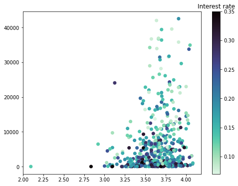

```python
# Available bankcard credit v.s. stated monthly income, by interest rate
fig = plt.figure(figsize=(8, 6))
log_data = np.log10(loan_samp.StatedMonthlyIncome)
plt.scatter(data = loan_samp, x = log_data, y = 'AvailableBankcardCredit',
            c = 'BorrowerRate', cmap = 'mako_r');
clb = plt.colorbar();
clb.ax.set_title('Interest rate');
```

### Interest Rate across Different Monthly Income, by Group of Income ranges

Higher income doesn't neccessarily mean lower interest rate, but in the range of below 0.10 of interest rate, most borrowers are with higher income.

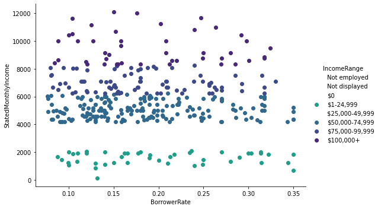

```python
# FacetGrid for interest rate across different monthly income, by group of income range
g = sb.FacetGrid(data = loan_samp, hue = 'IncomeRange',
                 height = 5, aspect=1.5, palette='viridis_r');
g.map(plt.scatter, 'BorrowerRate', 'StatedMonthlyIncome');
g.add_legend();
plt.show()
```

**Less terms and better statuses of loans means lower rates, but it's an indivisual's financial situation that eventually sets the rate. Borrowers with higher bankcard credits and income range, home owners have more chance of receiving lower interest rates.**  
The negative correlation between income range and interest rate (as observed in the bivariate exploration stage) is confirmed in multivariate exploration. Previously, I found `Term` has a positive correlation with rates, but it was not clear how borrowers' income ranges' (`IncomeRange`) negative correlation with rates affect this correlation. In multivariate explotation, it's observed that within each income range group, the rate increases as amount of terms increases, **but, for the same amount of terms, people with higher income are able to be granted lower interest rate, despite number of `Term`**.

Similarly, although `ProsperScore` has a negative correlation with rates, but whether the borrowers are **home owners (`IsBorrowerHomeowner`)still proven to decide whether they can get lower interest rate**, i.e., a homeowner who has the same score as a non-homeowner can enjoy lower rates.  
Also, interest rates decrease as income ranges increase, despite of different `LoanStatus`.  
Lower bank Card Credits Can be a Barrier to Lowest Rates.